# Risk Factor Analysis

## Outcome Variable

**Outcome Variable:** ever_swasted

## Predictor Variables

**Intervention Variable:** mhtcm

**Adjustment Set:**

- arm
- W_mage
- meducyrs
- feducyrs
- delta_W_mage
- delta_meducyrs
- delta_feducyrs

## Stratifying Variables

The analysis was stratified on these variable(s):

- agecat
- studyid
- country

## Data Summary

| agecat | studyid | country | mhtcm | ever_swasted | n_cell | n |
| --- | --- | --- | --- | --- | --- | --- |
| 0-24 months | ki0047075b-MAL-ED | BANGLADESH | >=155 cm | 0 | 23 | 254 |
| 0-24 months | ki0047075b-MAL-ED | BANGLADESH | >=155 cm | 1 | 2 | 254 |
| 0-24 months | ki0047075b-MAL-ED | BANGLADESH | <151 cm | 0 | 149 | 254 |
| 0-24 months | ki0047075b-MAL-ED | BANGLADESH | <151 cm | 1 | 14 | 254 |
| 0-24 months | ki0047075b-MAL-ED | BANGLADESH | [151-155) cm | 0 | 61 | 254 |
| 0-24 months | ki0047075b-MAL-ED | BANGLADESH | [151-155) cm | 1 | 5 | 254 |
| 0-24 months | ki0047075b-MAL-ED | BRAZIL | >=155 cm | 0 | 126 | 222 |
| 0-24 months | ki0047075b-MAL-ED | BRAZIL | >=155 cm | 1 | 4 | 222 |
| 0-24 months | ki0047075b-MAL-ED | BRAZIL | <151 cm | 0 | 53 | 222 |
| 0-24 months | ki0047075b-MAL-ED | BRAZIL | <151 cm | 1 | 0 | 222 |
| 0-24 months | ki0047075b-MAL-ED | BRAZIL | [151-155) cm | 0 | 39 | 222 |
| 0-24 months | ki0047075b-MAL-ED | BRAZIL | [151-155) cm | 1 | 0 | 222 |
| 0-24 months | ki0047075b-MAL-ED | INDIA | >=155 cm | 0 | 51 | 242 |
| 0-24 months | ki0047075b-MAL-ED | INDIA | >=155 cm | 1 | 4 | 242 |
| 0-24 months | ki0047075b-MAL-ED | INDIA | <151 cm | 0 | 99 | 242 |
| 0-24 months | ki0047075b-MAL-ED | INDIA | <151 cm | 1 | 16 | 242 |
| 0-24 months | ki0047075b-MAL-ED | INDIA | [151-155) cm | 0 | 66 | 242 |
| 0-24 months | ki0047075b-MAL-ED | INDIA | [151-155) cm | 1 | 6 | 242 |
| 0-24 months | ki0047075b-MAL-ED | NEPAL | >=155 cm | 0 | 40 | 238 |
| 0-24 months | ki0047075b-MAL-ED | NEPAL | >=155 cm | 1 | 1 | 238 |
| 0-24 months | ki0047075b-MAL-ED | NEPAL | <151 cm | 0 | 127 | 238 |
| 0-24 months | ki0047075b-MAL-ED | NEPAL | <151 cm | 1 | 6 | 238 |
| 0-24 months | ki0047075b-MAL-ED | NEPAL | [151-155) cm | 0 | 62 | 238 |
| 0-24 months | ki0047075b-MAL-ED | NEPAL | [151-155) cm | 1 | 2 | 238 |
| 0-24 months | ki0047075b-MAL-ED | PERU | >=155 cm | 0 | 60 | 290 |
| 0-24 months | ki0047075b-MAL-ED | PERU | >=155 cm | 1 | 0 | 290 |
| 0-24 months | ki0047075b-MAL-ED | PERU | <151 cm | 0 | 166 | 290 |
| 0-24 months | ki0047075b-MAL-ED | PERU | <151 cm | 1 | 3 | 290 |
| 0-24 months | ki0047075b-MAL-ED | PERU | [151-155) cm | 0 | 60 | 290 |
| 0-24 months | ki0047075b-MAL-ED | PERU | [151-155) cm | 1 | 1 | 290 |

[output cut: 378 more lines]

The following strata were considered:

- agecat: 0-24 months, studyid: ki0047075b-MAL-ED, country: BANGLADESH
- agecat: 0-24 months, studyid: ki0047075b-MAL-ED, country: BRAZIL
- agecat: 0-24 months, studyid: ki0047075b-MAL-ED, country: INDIA
- agecat: 0-24 months, studyid: ki0047075b-MAL-ED, country: NEPAL
- agecat: 0-24 months, studyid: ki0047075b-MAL-ED, country: PERU
- agecat: 0-24 months, studyid: ki0047075b-MAL-ED, country: SOUTH AFRICA
- agecat: 0-24 months, studyid: ki0047075b-MAL-ED, country: TANZANIA, UNITED REPUBLIC OF
- agecat: 0-24 months, studyid: ki1000304b-SAS-CompFeed, country: INDIA
- agecat: 0-24 months, studyid: ki1000304b-SAS-FoodSuppl, country: INDIA
- agecat: 0-24 months, studyid: ki1017093-NIH-Birth, country: BANGLADESH
- agecat: 0-24 months, studyid: ki1017093b-PROVIDE, country: BANGLADESH
- agecat: 0-24 months, studyid: ki1017093c-NIH-Crypto, country: BANGLADESH
- agecat: 0-24 months, studyid: ki1066203-TanzaniaChild2, country: TANZANIA, UNITED REPUBLIC OF
- agecat: 0-24 months, studyid: ki1101329-Keneba, country: GAMBIA
- agecat: 0-24 months, studyid: ki1112895-Guatemala BSC, country: GUATEMALA
- agecat: 0-24 months, studyid: ki1112895-iLiNS-Zinc, country: BURKINA FASO
- agecat: 0-24 months, studyid: ki1119695-PROBIT, country: BELARUS
- agecat: 0-24 months, studyid: ki1126311-ZVITAMBO, country: ZIMBABWE
- agecat: 0-24 months, studyid: ki1135781-COHORTS, country: GUATEMALA
- agecat: 0-24 months, studyid: ki1135781-COHORTS, country: INDIA
- agecat: 0-24 months, studyid: ki1135781-COHORTS, country: PHILIPPINES
- agecat: 0-24 months, studyid: ki1148112-LCNI-5, country: MALAWI
- agecat: 0-24 months, studyid: kiGH5241-JiVitA-3, country: BANGLADESH
- agecat: 0-6 months, studyid: ki0047075b-MAL-ED, country: BANGLADESH
- agecat: 0-6 months, studyid: ki0047075b-MAL-ED, country: BRAZIL
- agecat: 0-6 months, studyid: ki0047075b-MAL-ED, country: INDIA
- agecat: 0-6 months, studyid: ki0047075b-MAL-ED, country: NEPAL
- agecat: 0-6 months, studyid: ki0047075b-MAL-ED, country: PERU
- agecat: 0-6 months, studyid: ki0047075b-MAL-ED, country: SOUTH AFRICA
- agecat: 0-6 months, studyid: ki0047075b-MAL-ED, country: TANZANIA, UNITED REPUBLIC OF
- agecat: 0-6 months, studyid: ki1000304b-SAS-CompFeed, country: INDIA
- agecat: 0-6 months, studyid: ki1000304b-SAS-FoodSuppl, country: INDIA
- agecat: 0-6 months, studyid: ki1017093-NIH-Birth, country: BANGLADESH
- agecat: 0-6 months, studyid: ki1017093b-PROVIDE, country: BANGLADESH
- agecat: 0-6 months, studyid: ki1017093c-NIH-Crypto, country: BANGLADESH
- agecat: 0-6 months, studyid: ki1066203-TanzaniaChild2, country: TANZANIA, UNITED REPUBLIC OF
- agecat: 0-6 months, studyid: ki1101329-Keneba, country: GAMBIA
- agecat: 0-6 months, studyid: ki1112895-Guatemala BSC, country: GUATEMALA
- agecat: 0-6 months, studyid: ki1119695-PROBIT, country: BELARUS
- agecat: 0-6 months, studyid: ki1126311-ZVITAMBO, country: ZIMBABWE
- agecat: 0-6 months, studyid: ki1135781-COHORTS, country: GUATEMALA
- agecat: 0-6 months, studyid: ki1135781-COHORTS, country: INDIA
- agecat: 0-6 months, studyid: ki1135781-COHORTS, country: PHILIPPINES
- agecat: 0-6 months, studyid: ki1148112-LCNI-5, country: MALAWI
- agecat: 0-6 months, studyid: kiGH5241-JiVitA-3, country: BANGLADESH
- agecat: 6-24 months, studyid: ki0047075b-MAL-ED, country: BANGLADESH
- agecat: 6-24 months, studyid: ki0047075b-MAL-ED, country: BRAZIL
- agecat: 6-24 months, studyid: ki0047075b-MAL-ED, country: INDIA
- agecat: 6-24 months, studyid: ki0047075b-MAL-ED, country: NEPAL
- agecat: 6-24 months, studyid: ki0047075b-MAL-ED, country: PERU
- agecat: 6-24 months, studyid: ki0047075b-MAL-ED, country: SOUTH AFRICA
- agecat: 6-24 months, studyid: ki0047075b-MAL-ED, country: TANZANIA, UNITED REPUBLIC OF
- agecat: 6-24 months, studyid: ki1000304b-SAS-CompFeed, country: INDIA
- agecat: 6-24 months, studyid: ki1000304b-SAS-FoodSuppl, country: INDIA
- agecat: 6-24 months, studyid: ki1017093-NIH-Birth, country: BANGLADESH
- agecat: 6-24 months, studyid: ki1017093b-PROVIDE, country: BANGLADESH
- agecat: 6-24 months, studyid: ki1017093c-NIH-Crypto, country: BANGLADESH
- agecat: 6-24 months, studyid: ki1066203-TanzaniaChild2, country: TANZANIA, UNITED REPUBLIC OF
- agecat: 6-24 months, studyid: ki1101329-Keneba, country: GAMBIA
- agecat: 6-24 months, studyid: ki1112895-Guatemala BSC, country: GUATEMALA
- agecat: 6-24 months, studyid: ki1112895-iLiNS-Zinc, country: BURKINA FASO
- agecat: 6-24 months, studyid: ki1119695-PROBIT, country: BELARUS
- agecat: 6-24 months, studyid: ki1126311-ZVITAMBO, country: ZIMBABWE
- agecat: 6-24 months, studyid: ki1135781-COHORTS, country: GUATEMALA
- agecat: 6-24 months, studyid: ki1135781-COHORTS, country: INDIA
- agecat: 6-24 months, studyid: ki1135781-COHORTS, country: PHILIPPINES
- agecat: 6-24 months, studyid: ki1148112-LCNI-5, country: MALAWI
- agecat: 6-24 months, studyid: kiGH5241-JiVitA-3, country: BANGLADESH

### Dropped Strata

Some strata were dropped due to rare outcomes:

- agecat: 0-24 months, studyid: ki0047075b-MAL-ED, country: BANGLADESH
- agecat: 0-24 months, studyid: ki0047075b-MAL-ED, country: BRAZIL
- agecat: 0-24 months, studyid: ki0047075b-MAL-ED, country: INDIA
- agecat: 0-24 months, studyid: ki0047075b-MAL-ED, country: NEPAL
- agecat: 0-24 months, studyid: ki0047075b-MAL-ED, country: PERU
- agecat: 0-24 months, studyid: ki0047075b-MAL-ED, country: SOUTH AFRICA
- agecat: 0-24 months, studyid: ki0047075b-MAL-ED, country: TANZANIA, UNITED REPUBLIC OF
- agecat: 0-24 months, studyid: ki1112895-Guatemala BSC, country: GUATEMALA
- agecat: 0-24 months, studyid: ki1148112-LCNI-5, country: MALAWI
- agecat: 0-6 months, studyid: ki0047075b-MAL-ED, country: BANGLADESH
- agecat: 0-6 months, studyid: ki0047075b-MAL-ED, country: BRAZIL
- agecat: 0-6 months, studyid: ki0047075b-MAL-ED, country: INDIA
- agecat: 0-6 months, studyid: ki0047075b-MAL-ED, country: NEPAL
- agecat: 0-6 months, studyid: ki0047075b-MAL-ED, country: PERU
- agecat: 0-6 months, studyid: ki0047075b-MAL-ED, country: SOUTH AFRICA
- agecat: 0-6 months, studyid: ki0047075b-MAL-ED, country: TANZANIA, UNITED REPUBLIC OF
- agecat: 0-6 months, studyid: ki1000304b-SAS-FoodSuppl, country: INDIA
- agecat: 0-6 months, studyid: ki1112895-Guatemala BSC, country: GUATEMALA
- agecat: 0-6 months, studyid: ki1148112-LCNI-5, country: MALAWI
- agecat: 6-24 months, studyid: ki0047075b-MAL-ED, country: BANGLADESH
- agecat: 6-24 months, studyid: ki0047075b-MAL-ED, country: BRAZIL
- agecat: 6-24 months, studyid: ki0047075b-MAL-ED, country: INDIA
- agecat: 6-24 months, studyid: ki0047075b-MAL-ED, country: NEPAL
- agecat: 6-24 months, studyid: ki0047075b-MAL-ED, country: PERU
- agecat: 6-24 months, studyid: ki0047075b-MAL-ED, country: SOUTH AFRICA
- agecat: 6-24 months, studyid: ki0047075b-MAL-ED, country: TANZANIA, UNITED REPUBLIC OF
- agecat: 6-24 months, studyid: ki1017093b-PROVIDE, country: BANGLADESH
- agecat: 6-24 months, studyid: ki1017093c-NIH-Crypto, country: BANGLADESH
- agecat: 6-24 months, studyid: ki1112895-Guatemala BSC, country: GUATEMALA
- agecat: 6-24 months, studyid: ki1119695-PROBIT, country: BELARUS
- agecat: 6-24 months, studyid: ki1135781-COHORTS, country: GUATEMALA
- agecat: 6-24 months, studyid: ki1148112-LCNI-5, country: MALAWI

## Methods Detail

We’re interested in the causal parameters $E[Y_a]$ for all values of $a \in \mathcal{A}$. These parameters represent the mean outcome if, possibly contrary to fact, we intervened to set all units to have $A=a$. Under the randomization and positivity assumptions, these are identified by the statistical parameters $\psi_a=E_W[E_{Y|A,W}(Y|A=a,W)]$. In addition, we’re interested in the mean of $Y$, $E[Y]$ under no intervention (the observed mean). We will estimate these parameters by using SuperLearner to fit the relevant likelihood factors – $E_{Y|A,W}(Y|A=a,W)$ and $p(A=a|W)$, and then updating our likelihood fit using a joint TMLE.

For unadjusted analyses ($W=\{\}$), initial likelihoods were estimated using Lrnr_glm to estimate the simple $E(Y|A)$ and Lrnr_mean to estimate $p(A)$. For adjusted analyses, a small library containing Lrnr_glmnet, Lrnr_xgboost, and Lrnr_mean was used.

Having estimated these parameters, we will then use the delta method to estimate relative risks and attributable risks relative to a prespecified baseline level of $A$.

# Results Detail

## Results Plots

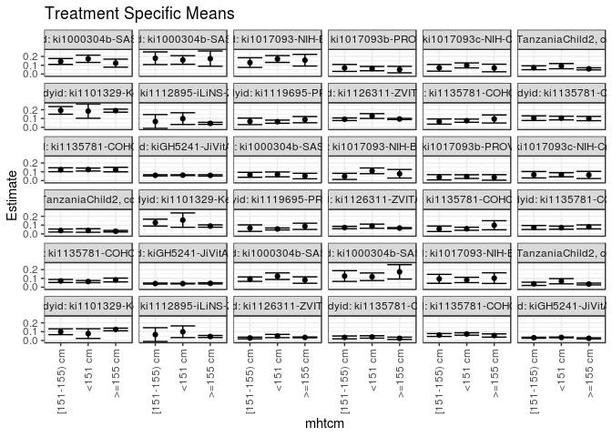

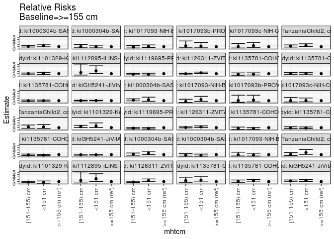

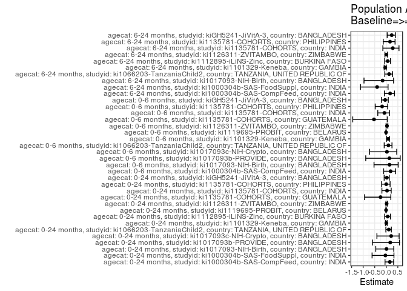

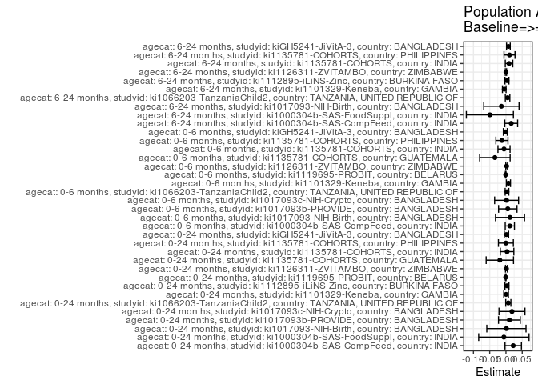

## Results Table

### Parameter: TSM

| agecat | studyid | country | intervention_level | baseline_level | estimate | ci_lower | ci_upper |
| --- | --- | --- | --- | --- | --- | --- | --- |
| 0-24 months | ki1000304b-SAS-CompFeed | INDIA | >=155 cm | NA | 0.1237326 | 0.0781151 | 0.1693500 |
| 0-24 months | ki1000304b-SAS-CompFeed | INDIA | <151 cm | NA | 0.1734044 | 0.1318102 | 0.2149986 |
| 0-24 months | ki1000304b-SAS-CompFeed | INDIA | [151-155) cm | NA | 0.1428501 | 0.1096628 | 0.1760374 |
| 0-24 months | ki1000304b-SAS-FoodSuppl | INDIA | >=155 cm | NA | 0.1751483 | 0.0886704 | 0.2616263 |
| 0-24 months | ki1000304b-SAS-FoodSuppl | INDIA | <151 cm | NA | 0.1598479 | 0.1110859 | 0.2086098 |
| 0-24 months | ki1000304b-SAS-FoodSuppl | INDIA | [151-155) cm | NA | 0.1798092 | 0.1078255 | 0.2517929 |
| 0-24 months | ki1017093-NIH-Birth | BANGLADESH | >=155 cm | NA | 0.1572791 | 0.0906165 | 0.2239418 |
| 0-24 months | ki1017093-NIH-Birth | BANGLADESH | <151 cm | NA | 0.1711561 | 0.1322680 | 0.2100442 |
| 0-24 months | ki1017093-NIH-Birth | BANGLADESH | [151-155) cm | NA | 0.1301656 | 0.0753073 | 0.1850239 |
| 0-24 months | ki1017093b-PROVIDE | BANGLADESH | >=155 cm | NA | 0.0507246 | 0.0140860 | 0.0873632 |
| 0-24 months | ki1017093b-PROVIDE | BANGLADESH | <151 cm | NA | 0.0616622 | 0.0372331 | 0.0860913 |
| 0-24 months | ki1017093b-PROVIDE | BANGLADESH | [151-155) cm | NA | 0.0696203 | 0.0299064 | 0.1093341 |
| 0-24 months | ki1017093c-NIH-Crypto | BANGLADESH | >=155 cm | NA | 0.0689311 | 0.0256612 | 0.1122010 |
| 0-24 months | ki1017093c-NIH-Crypto | BANGLADESH | <151 cm | NA | 0.0981615 | 0.0700442 | 0.1262789 |
| 0-24 months | ki1017093c-NIH-Crypto | BANGLADESH | [151-155) cm | NA | 0.0709670 | 0.0327113 | 0.1092227 |
| 0-24 months | ki1066203-TanzaniaChild2 | TANZANIA, UNITED REPUBLIC OF | >=155 cm | NA | 0.0589244 | 0.0469648 | 0.0708840 |
| 0-24 months | ki1066203-TanzaniaChild2 | TANZANIA, UNITED REPUBLIC OF | <151 cm | NA | 0.0896569 | 0.0600679 | 0.1192459 |
| 0-24 months | ki1066203-TanzaniaChild2 | TANZANIA, UNITED REPUBLIC OF | [151-155) cm | NA | 0.0713102 | 0.0491508 | 0.0934696 |
| 0-24 months | ki1101329-Keneba | GAMBIA | >=155 cm | NA | 0.1894189 | 0.1723144 | 0.2065233 |
| 0-24 months | ki1101329-Keneba | GAMBIA | <151 cm | NA | 0.1844946 | 0.1031923 | 0.2657969 |
| 0-24 months | ki1101329-Keneba | GAMBIA | [151-155) cm | NA | 0.1920391 | 0.1488348 | 0.2352433 |
| 0-24 months | ki1112895-iLiNS-Zinc | BURKINA FASO | >=155 cm | NA | 0.0448276 | 0.0330790 | 0.0565762 |
| 0-24 months | ki1112895-iLiNS-Zinc | BURKINA FASO | <151 cm | NA | 0.0989011 | 0.0320763 | 0.1657259 |
| 0-24 months | ki1112895-iLiNS-Zinc | BURKINA FASO | [151-155) cm | NA | 0.0663717 | -0.0121057 | 0.1448490 |
| 0-24 months | ki1119695-PROBIT | BELARUS | >=155 cm | NA | 0.0872001 | 0.0518410 | 0.1225591 |
| 0-24 months | ki1119695-PROBIT | BELARUS | <151 cm | NA | 0.0640000 | 0.0461518 | 0.0818482 |
| 0-24 months | ki1119695-PROBIT | BELARUS | [151-155) cm | NA | 0.0678392 | 0.0306458 | 0.1050326 |
| 0-24 months | ki1126311-ZVITAMBO | ZIMBABWE | >=155 cm | NA | 0.0947093 | 0.0882159 | 0.1012028 |
| 0-24 months | ki1126311-ZVITAMBO | ZIMBABWE | <151 cm | NA | 0.1281701 | 0.1008659 | 0.1554744 |
| 0-24 months | ki1126311-ZVITAMBO | ZIMBABWE | [151-155) cm | NA | 0.0918504 | 0.0768846 | 0.1068161 |

[output cut: 78 more lines]

### Parameter: E(Y)

| agecat | studyid | country | intervention_level | baseline_level | estimate | ci_lower | ci_upper |
| --- | --- | --- | --- | --- | --- | --- | --- |
| 0-24 months | ki1000304b-SAS-CompFeed | INDIA | NA | NA | 0.1460432 | 0.1145875 | 0.1774988 |
| 0-24 months | ki1000304b-SAS-FoodSuppl | INDIA | NA | NA | 0.1687042 | 0.1323664 | 0.2050420 |
| 0-24 months | ki1017093-NIH-Birth | BANGLADESH | NA | NA | 0.1586538 | 0.1299648 | 0.1873429 |
| 0-24 months | ki1017093b-PROVIDE | BANGLADESH | NA | NA | 0.0612855 | 0.0430966 | 0.0794744 |
| 0-24 months | ki1017093c-NIH-Crypto | BANGLADESH | NA | NA | 0.0874172 | 0.0672569 | 0.1075775 |
| 0-24 months | ki1066203-TanzaniaChild2 | TANZANIA, UNITED REPUBLIC OF | NA | NA | 0.0661297 | 0.0560993 | 0.0761601 |
| 0-24 months | ki1101329-Keneba | GAMBIA | NA | NA | 0.1898110 | 0.1742287 | 0.2053933 |
| 0-24 months | ki1112895-iLiNS-Zinc | BURKINA FASO | NA | NA | 0.0478707 | 0.0359037 | 0.0598376 |
| 0-24 months | ki1119695-PROBIT | BELARUS | NA | NA | 0.0864278 | 0.0516339 | 0.1212218 |
| 0-24 months | ki1126311-ZVITAMBO | ZIMBABWE | NA | NA | 0.0962360 | 0.0904057 | 0.1020663 |
| 0-24 months | ki1135781-COHORTS | GUATEMALA | NA | NA | 0.0760784 | 0.0615201 | 0.0906368 |
| 0-24 months | ki1135781-COHORTS | INDIA | NA | NA | 0.1034121 | 0.0897349 | 0.1170893 |
| 0-24 months | ki1135781-COHORTS | PHILIPPINES | NA | NA | 0.1254516 | 0.1136848 | 0.1372183 |
| 0-24 months | kiGH5241-JiVitA-3 | BANGLADESH | NA | NA | 0.0609979 | 0.0575023 | 0.0644934 |
| 0-6 months | ki1000304b-SAS-CompFeed | INDIA | NA | NA | 0.0636298 | 0.0408673 | 0.0863923 |
| 0-6 months | ki1017093-NIH-Birth | BANGLADESH | NA | NA | 0.0900322 | 0.0675202 | 0.1125442 |
| 0-6 months | ki1017093b-PROVIDE | BANGLADESH | NA | NA | 0.0418535 | 0.0266676 | 0.0570395 |
| 0-6 months | ki1017093c-NIH-Crypto | BANGLADESH | NA | NA | 0.0662252 | 0.0484753 | 0.0839750 |
| 0-6 months | ki1066203-TanzaniaChild2 | TANZANIA, UNITED REPUBLIC OF | NA | NA | 0.0334888 | 0.0262272 | 0.0407503 |
| 0-6 months | ki1101329-Keneba | GAMBIA | NA | NA | 0.0968041 | 0.0843285 | 0.1092796 |
| 0-6 months | ki1119695-PROBIT | BELARUS | NA | NA | 0.0850444 | 0.0501371 | 0.1199517 |
| 0-6 months | ki1126311-ZVITAMBO | ZIMBABWE | NA | NA | 0.0681168 | 0.0631263 | 0.0731073 |
| 0-6 months | ki1135781-COHORTS | GUATEMALA | NA | NA | 0.0641148 | 0.0492559 | 0.0789738 |
| 0-6 months | ki1135781-COHORTS | INDIA | NA | NA | 0.0735373 | 0.0616816 | 0.0853930 |
| 0-6 months | ki1135781-COHORTS | PHILIPPINES | NA | NA | 0.0693167 | 0.0602923 | 0.0783411 |
| 0-6 months | kiGH5241-JiVitA-3 | BANGLADESH | NA | NA | 0.0413613 | 0.0383739 | 0.0443486 |
| 6-24 months | ki1000304b-SAS-CompFeed | INDIA | NA | NA | 0.0971026 | 0.0697212 | 0.1244840 |
| 6-24 months | ki1000304b-SAS-FoodSuppl | INDIA | NA | NA | 0.1246883 | 0.0923131 | 0.1570635 |
| 6-24 months | ki1017093-NIH-Birth | BANGLADESH | NA | NA | 0.0885609 | 0.0646203 | 0.1125014 |
| 6-24 months | ki1066203-TanzaniaChild2 | TANZANIA, UNITED REPUBLIC OF | NA | NA | 0.0408060 | 0.0321006 | 0.0495115 |
| 6-24 months | ki1101329-Keneba | GAMBIA | NA | NA | 0.1195185 | 0.1063325 | 0.1327045 |
| 6-24 months | ki1112895-iLiNS-Zinc | BURKINA FASO | NA | NA | 0.0478707 | 0.0359037 | 0.0598376 |
| 6-24 months | ki1126311-ZVITAMBO | ZIMBABWE | NA | NA | 0.0345547 | 0.0306996 | 0.0384098 |
| 6-24 months | ki1135781-COHORTS | INDIA | NA | NA | 0.0336408 | 0.0254069 | 0.0418747 |
| 6-24 months | ki1135781-COHORTS | PHILIPPINES | NA | NA | 0.0669277 | 0.0576848 | 0.0761707 |
| 6-24 months | kiGH5241-JiVitA-3 | BANGLADESH | NA | NA | 0.0318896 | 0.0289915 | 0.0347877 |

### Parameter: RR

| agecat | studyid | country | intervention_level | baseline_level | estimate | ci_lower | ci_upper |
| --- | --- | --- | --- | --- | --- | --- | --- |
| 0-24 months | ki1000304b-SAS-CompFeed | INDIA | >=155 cm | >=155 cm | 1.0000000 | 1.0000000 | 1.0000000 |
| 0-24 months | ki1000304b-SAS-CompFeed | INDIA | <151 cm | >=155 cm | 1.4014455 | 0.9583816 | 2.0493397 |
| 0-24 months | ki1000304b-SAS-CompFeed | INDIA | [151-155) cm | >=155 cm | 1.1545073 | 0.8550998 | 1.5587502 |
| 0-24 months | ki1000304b-SAS-FoodSuppl | INDIA | >=155 cm | >=155 cm | 1.0000000 | 1.0000000 | 1.0000000 |
| 0-24 months | ki1000304b-SAS-FoodSuppl | INDIA | <151 cm | >=155 cm | 0.9126427 | 0.5109343 | 1.6301836 |
| 0-24 months | ki1000304b-SAS-FoodSuppl | INDIA | [151-155) cm | >=155 cm | 1.0266109 | 0.5440961 | 1.9370292 |
| 0-24 months | ki1017093-NIH-Birth | BANGLADESH | >=155 cm | >=155 cm | 1.0000000 | 1.0000000 | 1.0000000 |
| 0-24 months | ki1017093-NIH-Birth | BANGLADESH | <151 cm | >=155 cm | 1.0882314 | 0.6725816 | 1.7607492 |
| 0-24 months | ki1017093-NIH-Birth | BANGLADESH | [151-155) cm | >=155 cm | 0.8276086 | 0.4551631 | 1.5048143 |
| 0-24 months | ki1017093b-PROVIDE | BANGLADESH | >=155 cm | >=155 cm | 1.0000000 | 1.0000000 | 1.0000000 |
| 0-24 months | ki1017093b-PROVIDE | BANGLADESH | <151 cm | >=155 cm | 1.2156262 | 0.5333591 | 2.7706417 |
| 0-24 months | ki1017093b-PROVIDE | BANGLADESH | [151-155) cm | >=155 cm | 1.3725136 | 0.5467589 | 3.4453826 |
| 0-24 months | ki1017093c-NIH-Crypto | BANGLADESH | >=155 cm | >=155 cm | 1.0000000 | 1.0000000 | 1.0000000 |
| 0-24 months | ki1017093c-NIH-Crypto | BANGLADESH | <151 cm | >=155 cm | 1.4240524 | 0.7139596 | 2.8403923 |
| 0-24 months | ki1017093c-NIH-Crypto | BANGLADESH | [151-155) cm | >=155 cm | 1.0295348 | 0.4501807 | 2.3544811 |
| 0-24 months | ki1066203-TanzaniaChild2 | TANZANIA, UNITED REPUBLIC OF | >=155 cm | >=155 cm | 1.0000000 | 1.0000000 | 1.0000000 |
| 0-24 months | ki1066203-TanzaniaChild2 | TANZANIA, UNITED REPUBLIC OF | <151 cm | >=155 cm | 1.5215592 | 1.0328127 | 2.2415897 |
| 0-24 months | ki1066203-TanzaniaChild2 | TANZANIA, UNITED REPUBLIC OF | [151-155) cm | >=155 cm | 1.2101990 | 0.8348737 | 1.7542553 |
| 0-24 months | ki1101329-Keneba | GAMBIA | >=155 cm | >=155 cm | 1.0000000 | 1.0000000 | 1.0000000 |
| 0-24 months | ki1101329-Keneba | GAMBIA | <151 cm | >=155 cm | 0.9740031 | 0.6211239 | 1.5273638 |
| 0-24 months | ki1101329-Keneba | GAMBIA | [151-155) cm | >=155 cm | 1.0138329 | 0.7955335 | 1.2920351 |
| 0-24 months | ki1112895-iLiNS-Zinc | BURKINA FASO | >=155 cm | >=155 cm | 1.0000000 | 1.0000000 | 1.0000000 |
| 0-24 months | ki1112895-iLiNS-Zinc | BURKINA FASO | <151 cm | >=155 cm | 2.2062552 | 1.1131512 | 4.3727771 |
| 0-24 months | ki1112895-iLiNS-Zinc | BURKINA FASO | [151-155) cm | >=155 cm | 1.4805990 | 0.4280421 | 5.1213962 |
| 0-24 months | ki1119695-PROBIT | BELARUS | >=155 cm | >=155 cm | 1.0000000 | 1.0000000 | 1.0000000 |
| 0-24 months | ki1119695-PROBIT | BELARUS | <151 cm | >=155 cm | 0.7339444 | 0.4513006 | 1.1936045 |
| 0-24 months | ki1119695-PROBIT | BELARUS | [151-155) cm | >=155 cm | 0.7779719 | 0.5298749 | 1.1422323 |
| 0-24 months | ki1126311-ZVITAMBO | ZIMBABWE | >=155 cm | >=155 cm | 1.0000000 | 1.0000000 | 1.0000000 |
| 0-24 months | ki1126311-ZVITAMBO | ZIMBABWE | <151 cm | >=155 cm | 1.3532995 | 1.0819188 | 1.6927513 |
| 0-24 months | ki1126311-ZVITAMBO | ZIMBABWE | [151-155) cm | >=155 cm | 0.9698130 | 0.8126787 | 1.1573298 |

[output cut: 78 more lines]

### Parameter: PAR

| agecat | studyid | country | intervention_level | baseline_level | estimate | ci_lower | ci_upper |
| --- | --- | --- | --- | --- | --- | --- | --- |
| 0-24 months | ki1000304b-SAS-CompFeed | INDIA | >=155 cm | NA | 0.0223106 | -0.0029468 | 0.0475680 |
| 0-24 months | ki1000304b-SAS-FoodSuppl | INDIA | >=155 cm | NA | -0.0064442 | -0.0838439 | 0.0709556 |
| 0-24 months | ki1017093-NIH-Birth | BANGLADESH | >=155 cm | NA | 0.0013747 | -0.0589324 | 0.0616818 |
| 0-24 months | ki1017093b-PROVIDE | BANGLADESH | >=155 cm | NA | 0.0105609 | -0.0228968 | 0.0440185 |
| 0-24 months | ki1017093c-NIH-Crypto | BANGLADESH | >=155 cm | NA | 0.0184861 | -0.0214553 | 0.0584276 |
| 0-24 months | ki1066203-TanzaniaChild2 | TANZANIA, UNITED REPUBLIC OF | >=155 cm | NA | 0.0072054 | -0.0007175 | 0.0151282 |
| 0-24 months | ki1101329-Keneba | GAMBIA | >=155 cm | NA | 0.0003922 | -0.0067721 | 0.0075564 |
| 0-24 months | ki1112895-iLiNS-Zinc | BURKINA FASO | >=155 cm | NA | 0.0030431 | -0.0031079 | 0.0091941 |
| 0-24 months | ki1119695-PROBIT | BELARUS | >=155 cm | NA | -0.0007722 | -0.0017964 | 0.0002520 |
| 0-24 months | ki1126311-ZVITAMBO | ZIMBABWE | >=155 cm | NA | 0.0015267 | -0.0014882 | 0.0045416 |
| 0-24 months | ki1135781-COHORTS | GUATEMALA | >=155 cm | NA | -0.0188537 | -0.0608929 | 0.0231855 |
| 0-24 months | ki1135781-COHORTS | INDIA | >=155 cm | NA | 0.0034624 | -0.0172918 | 0.0242166 |
| 0-24 months | ki1135781-COHORTS | PHILIPPINES | >=155 cm | NA | -0.0002511 | -0.0232155 | 0.0227133 |
| 0-24 months | kiGH5241-JiVitA-3 | BANGLADESH | >=155 cm | NA | 0.0015538 | -0.0051782 | 0.0082858 |
| 0-6 months | ki1000304b-SAS-CompFeed | INDIA | >=155 cm | NA | 0.0118951 | -0.0022618 | 0.0260520 |
| 0-6 months | ki1017093-NIH-Birth | BANGLADESH | >=155 cm | NA | 0.0124459 | -0.0322217 | 0.0571136 |
| 0-6 months | ki1017093b-PROVIDE | BANGLADESH | >=155 cm | NA | 0.0056216 | -0.0227065 | 0.0339497 |
| 0-6 months | ki1017093c-NIH-Crypto | BANGLADESH | >=155 cm | NA | 0.0019395 | -0.0348689 | 0.0387478 |
| 0-6 months | ki1066203-TanzaniaChild2 | TANZANIA, UNITED REPUBLIC OF | >=155 cm | NA | 0.0031512 | -0.0024909 | 0.0087933 |
| 0-6 months | ki1101329-Keneba | GAMBIA | >=155 cm | NA | 0.0075593 | 0.0011957 | 0.0139228 |
| 0-6 months | ki1119695-PROBIT | BELARUS | >=155 cm | NA | -0.0008688 | -0.0017502 | 0.0000125 |
| 0-6 months | ki1126311-ZVITAMBO | ZIMBABWE | >=155 cm | NA | 0.0021196 | -0.0005182 | 0.0047575 |
| 0-6 months | ki1135781-COHORTS | GUATEMALA | >=155 cm | NA | -0.0340747 | -0.0809479 | 0.0127986 |
| 0-6 months | ki1135781-COHORTS | INDIA | >=155 cm | NA | -0.0060375 | -0.0246438 | 0.0125689 |
| 0-6 months | ki1135781-COHORTS | PHILIPPINES | >=155 cm | NA | -0.0124269 | -0.0310487 | 0.0061950 |
| 0-6 months | kiGH5241-JiVitA-3 | BANGLADESH | >=155 cm | NA | -0.0020357 | -0.0081102 | 0.0040388 |
| 6-24 months | ki1000304b-SAS-CompFeed | INDIA | >=155 cm | NA | 0.0161467 | -0.0035807 | 0.0358740 |
| 6-24 months | ki1000304b-SAS-FoodSuppl | INDIA | >=155 cm | NA | -0.0494909 | -0.1218278 | 0.0228460 |
| 6-24 months | ki1017093-NIH-Birth | BANGLADESH | >=155 cm | NA | -0.0140527 | -0.0683138 | 0.0402084 |
| 6-24 months | ki1066203-TanzaniaChild2 | TANZANIA, UNITED REPUBLIC OF | >=155 cm | NA | 0.0049940 | -0.0019604 | 0.0119485 |
| 6-24 months | ki1101329-Keneba | GAMBIA | >=155 cm | NA | -0.0052865 | -0.0108741 | 0.0003010 |
| 6-24 months | ki1112895-iLiNS-Zinc | BURKINA FASO | >=155 cm | NA | 0.0030431 | -0.0031079 | 0.0091941 |
| 6-24 months | ki1126311-ZVITAMBO | ZIMBABWE | >=155 cm | NA | -0.0000329 | -0.0019921 | 0.0019263 |
| 6-24 months | ki1135781-COHORTS | INDIA | >=155 cm | NA | 0.0094902 | -0.0020903 | 0.0210707 |
| 6-24 months | ki1135781-COHORTS | PHILIPPINES | >=155 cm | NA | 0.0108693 | -0.0060661 | 0.0278047 |
| 6-24 months | kiGH5241-JiVitA-3 | BANGLADESH | >=155 cm | NA | 0.0074991 | 0.0018589 | 0.0131392 |

### Parameter: PAF

| agecat | studyid | country | intervention_level | baseline_level | estimate | ci_lower | ci_upper |
| --- | --- | --- | --- | --- | --- | --- | --- |
| 0-24 months | ki1000304b-SAS-CompFeed | INDIA | >=155 cm | NA | 0.1527672 | -0.0540393 | 0.3189976 |
| 0-24 months | ki1000304b-SAS-FoodSuppl | INDIA | >=155 cm | NA | -0.0381982 | -0.6148332 | 0.3325283 |
| 0-24 months | ki1017093-NIH-Birth | BANGLADESH | >=155 cm | NA | 0.0086648 | -0.4546037 | 0.3243895 |
| 0-24 months | ki1017093b-PROVIDE | BANGLADESH | >=155 cm | NA | 0.1723224 | -0.5965976 | 0.5709312 |
| 0-24 months | ki1017093c-NIH-Crypto | BANGLADESH | >=155 cm | NA | 0.2114698 | -0.4052026 | 0.5575159 |
| 0-24 months | ki1066203-TanzaniaChild2 | TANZANIA, UNITED REPUBLIC OF | >=155 cm | NA | 0.1089579 | -0.0181571 | 0.2202029 |
| 0-24 months | ki1101329-Keneba | GAMBIA | >=155 cm | NA | 0.0020660 | -0.0364002 | 0.0391045 |
| 0-24 months | ki1112895-iLiNS-Zinc | BURKINA FASO | >=155 cm | NA | 0.0635692 | -0.0699048 | 0.1803918 |
| 0-24 months | ki1119695-PROBIT | BELARUS | >=155 cm | NA | -0.0089348 | -0.0193427 | 0.0013668 |
| 0-24 months | ki1126311-ZVITAMBO | ZIMBABWE | >=155 cm | NA | 0.0158638 | -0.0159579 | 0.0466887 |
| 0-24 months | ki1135781-COHORTS | GUATEMALA | >=155 cm | NA | -0.2478188 | -0.9395980 | 0.1972297 |
| 0-24 months | ki1135781-COHORTS | INDIA | >=155 cm | NA | 0.0334815 | -0.1895216 | 0.2146775 |
| 0-24 months | ki1135781-COHORTS | PHILIPPINES | >=155 cm | NA | -0.0020016 | -0.2028433 | 0.1653050 |
| 0-24 months | kiGH5241-JiVitA-3 | BANGLADESH | >=155 cm | NA | 0.0254732 | -0.0913119 | 0.1297608 |
| 0-6 months | ki1000304b-SAS-CompFeed | INDIA | >=155 cm | NA | 0.1869426 | -0.1127012 | 0.4058942 |
| 0-6 months | ki1017093-NIH-Birth | BANGLADESH | >=155 cm | NA | 0.1382389 | -0.5307819 | 0.5148674 |
| 0-6 months | ki1017093b-PROVIDE | BANGLADESH | >=155 cm | NA | 0.1343168 | -0.8884265 | 0.6031577 |
| 0-6 months | ki1017093c-NIH-Crypto | BANGLADESH | >=155 cm | NA | 0.0292857 | -0.7208215 | 0.4524207 |
| 0-6 months | ki1066203-TanzaniaChild2 | TANZANIA, UNITED REPUBLIC OF | >=155 cm | NA | 0.0940981 | -0.0898196 | 0.2469778 |
| 0-6 months | ki1101329-Keneba | GAMBIA | >=155 cm | NA | 0.0780882 | 0.0106404 | 0.1409379 |
| 0-6 months | ki1119695-PROBIT | BELARUS | >=155 cm | NA | -0.0102163 | -0.0189529 | -0.0015546 |
| 0-6 months | ki1126311-ZVITAMBO | ZIMBABWE | >=155 cm | NA | 0.0311173 | -0.0083328 | 0.0690239 |
| 0-6 months | ki1135781-COHORTS | GUATEMALA | >=155 cm | NA | -0.5314631 | -1.4505444 | 0.0429150 |
| 0-6 months | ki1135781-COHORTS | INDIA | >=155 cm | NA | -0.0821006 | -0.3668029 | 0.1432988 |
| 0-6 months | ki1135781-COHORTS | PHILIPPINES | >=155 cm | NA | -0.1792766 | -0.4799811 | 0.0603304 |
| 0-6 months | kiGH5241-JiVitA-3 | BANGLADESH | >=155 cm | NA | -0.0492168 | -0.2067230 | 0.0877311 |
| 6-24 months | ki1000304b-SAS-CompFeed | INDIA | >=155 cm | NA | 0.1662846 | -0.0814134 | 0.3572473 |
| 6-24 months | ki1000304b-SAS-FoodSuppl | INDIA | >=155 cm | NA | -0.3969172 | -1.1149992 | 0.0773625 |
| 6-24 months | ki1017093-NIH-Birth | BANGLADESH | >=155 cm | NA | -0.1586785 | -0.9639819 | 0.3164214 |
| 6-24 months | ki1066203-TanzaniaChild2 | TANZANIA, UNITED REPUBLIC OF | >=155 cm | NA | 0.1223841 | -0.0636698 | 0.2758940 |
| 6-24 months | ki1101329-Keneba | GAMBIA | >=155 cm | NA | -0.0442317 | -0.0918533 | 0.0013129 |
| 6-24 months | ki1112895-iLiNS-Zinc | BURKINA FASO | >=155 cm | NA | 0.0635692 | -0.0699048 | 0.1803918 |
| 6-24 months | ki1126311-ZVITAMBO | ZIMBABWE | >=155 cm | NA | -0.0009519 | -0.0592866 | 0.0541704 |
| 6-24 months | ki1135781-COHORTS | INDIA | >=155 cm | NA | 0.2821032 | -0.1479576 | 0.5510498 |
| 6-24 months | ki1135781-COHORTS | PHILIPPINES | >=155 cm | NA | 0.1624035 | -0.1318098 | 0.3801362 |
| 6-24 months | kiGH5241-JiVitA-3 | BANGLADESH | >=155 cm | NA | 0.2351575 | 0.0388091 | 0.3913967 |